# UCI Adult Dataset - EDA

## Exploratory Data Analysis (EDA)

Link to the dataset: https://archive.ics.uci.edu/ml/datasets/Adult

### Objective

This is a classification problem. Objective of the project is to determine whether a person makes $50K or not given the various demographic factors and to identify which factors are the most contributing in predicting or detrmining the income.

### Downloading the Dataset

- adult.data - contains 32,561 instances
- adult.names - contains the column names and legends
- adult.test - contains 16,281 instances

We will merge the adult.data and adult.test datasets vertically for our project as we will split them through train-test split later on

Notably, we need to change all 3 files to .csv to be able to upload to Jupyter notebook

### Dataset Attributes

This is a multivariate datatset, as a result we will need to consider multiple variables, their relationship and influence on the target valrable - income (>50K or <50K).

**Attribute characteristic:** Both categorical and integer attributes are used  
**Number of instances:** 48,842  
**Number of attributes:** 14  
**Missing values:** Yes

#### List of Attributes:

- **Age:** continuous
- **Workclass:** Private, Self-emp-not-inc, Self-emp-inc, Federal-gov, Local-gov, State-gov, Without-pay, Never-worked.
- **fnlwgt:** final weight; continuous
- **Education:** Bachelors, Some-college, 11th, HS-grad, Prof-school, Assoc-acdm, Assoc-voc, 9th, 7th-8th, 12th, Masters, 1st-4th, 10th, Doctorate, 5th-6th, Preschool.
- **Education-num:** continuous.
- **Marital-status:** Married-civ-spouse, Divorced, Never-married, Separated, Widowed, Married-spouse-absent, Married-AF-spouse.
- **Occupation:** Tech-support, Craft-repair, Other-service, Sales, Exec-managerial, Prof-specialty, Handlers-cleaners, Machine-op-inspct, Adm-clerical, Farming-fishing, Transport-moving, Priv-house-serv, Protective-serv, Armed-Forces.
- **Relationship:** Wife, Own-child, Husband, Not-in-family, Other-relative, Unmarried.
- **Race:** White, Asian-Pac-Islander, Amer-Indian-Eskimo, Other, Black.
- **Sex:** Female, Male.
- **Capital-gain:** continuous.
- **Capital-loss:** continuous.
- **Hours-per-week:** continuous.
- **Native-country:** United-States, Cambodia, England, Puerto-Rico, Canada, Germany, Outlying-US(Guam-USVI-etc), India, Japan, Greece, South, China, Cuba, Iran, Honduras, Philippines, Italy, Poland, Jamaica, Vietnam, Mexico, Portugal, Ireland, France, Dominican-Republic, Laos, Ecuador, Taiwan, Haiti, Columbia, Hungary, Guatemala, Nicaragua, Scotland, Thailand, Yugoslavia, El-Salvador, Trinadad&Tobago, Peru, Hong, Holand-Netherlands.

### Loading the libraries

```python
import pandas as pd
import numpy as np
import matplotlib.pyplot as plt
import seaborn as sns
import plotly.express as px
```

### Loading the dataset to notebook

```python
df1 = pd.read_csv('adult_data.csv', header = None)

# header is none as in the original dataset column names are in a separate file
```

```python
df2 = pd.read_csv('adult_test.csv', header = None)
```

```python
# merging the 2 datasets vertically for our project

df = pd.concat([df1, df2], ignore_index = True)
```

```python
df.shape
```

```
(48842, 15)
```

The original dataset does not have the column names in the same file as the data instances. Hence, when we load the data it starts from first instance instead of the heading. To correct this, we will need to create a list with column names separately and assign it to header

```python
column_names = ['age', 'workclass', 'fnlwgt', 'education', 'education-num', 'marital-status',
                'occupation', 'relationship','race', 'sex', 'capital-gain', 'capital-loss', 'hours-per-week',
                'Native-country', 'target income']
df.columns = column_names
df.head()
```

|  | age | workclass | fnlwgt | education | education-num | marital-status | occupation | relationship | race | sex | capital-gain | capital-loss | hours-per-week | Native-country | target income |
| --- | --- | --- | --- | --- | --- | --- | --- | --- | --- | --- | --- | --- | --- | --- | --- |
| 0 | 39 | State-gov | 77516 | Bachelors | 13 | Never-married | Adm-clerical | Not-in-family | White | Male | 2174 | 0 | 40 | United-States | <=50K |
| 1 | 50 | Self-emp-not-inc | 83311 | Bachelors | 13 | Married-civ-spouse | Exec-managerial | Husband | White | Male | 0 | 0 | 13 | United-States | <=50K |
| 2 | 38 | Private | 215646 | HS-grad | 9 | Divorced | Handlers-cleaners | Not-in-family | White | Male | 0 | 0 | 40 | United-States | <=50K |
| 3 | 53 | Private | 234721 | 11th | 7 | Married-civ-spouse | Handlers-cleaners | Husband | Black | Male | 0 | 0 | 40 | United-States | <=50K |
| 4 | 28 | Private | 338409 | Bachelors | 13 | Married-civ-spouse | Prof-specialty | Wife | Black | Female | 0 | 0 | 40 | Cuba | <=50K |

### Understanding the Data Types

```python
df.dtypes
```

```
age                int64
workclass         object
fnlwgt             int64
education         object
education-num      int64
marital-status    object
occupation        object
relationship      object
race              object
sex               object
capital-gain       int64
capital-loss       int64
hours-per-week     int64
Native-country    object
target income     object
dtype: object
```

```python
# converting the data types to best suitable data types (for example: from object to string)
df = df.convert_dtypes()
df.dtypes
```

```
age                Int64
workclass         string
fnlwgt             Int64
education         string
education-num      Int64
marital-status    string
occupation        string
relationship      string
race              string
sex               string
capital-gain       Int64
capital-loss       Int64
hours-per-week     Int64
Native-country    string
target income     string
dtype: object
```

```python
df.describe().T
# No missing values are noticed for the numeric columns
# We will also drop the attributes that are not necessary for our target variable
# such as - 'fnlwgt', 'capital-gain', 'capital-loss', 'relationship'
```

|  | count | mean | std | min | 25% | 50% | 75% | max |
| --- | --- | --- | --- | --- | --- | --- | --- | --- |
| age | 48842.0 | 38.643585 | 13.710510 | 17.0 | 28.0 | 37.0 | 48.0 | 90.0 |
| fnlwgt | 48842.0 | 189664.134597 | 105604.025423 | 12285.0 | 117550.5 | 178144.5 | 237642.0 | 1490400.0 |
| education-num | 48842.0 | 10.078089 | 2.570973 | 1.0 | 9.0 | 10.0 | 12.0 | 16.0 |
| capital-gain | 48842.0 | 1079.067626 | 7452.019058 | 0.0 | 0.0 | 0.0 | 0.0 | 99999.0 |
| capital-loss | 48842.0 | 87.502314 | 403.004552 | 0.0 | 0.0 | 0.0 | 0.0 | 4356.0 |
| hours-per-week | 48842.0 | 40.422382 | 12.391444 | 1.0 | 40.0 | 40.0 | 45.0 | 99.0 |

### Dropping irrelevant attributes

```python
df = df.drop(['fnlwgt', 'capital-gain', 'capital-loss', 'relationship'], axis=1)
```

```python
df.head()
```

|  | age | workclass | education | education-num | marital-status | occupation | race | sex | hours-per-week | Native-country | target income |
| --- | --- | --- | --- | --- | --- | --- | --- | --- | --- | --- | --- |
| 0 | 39 | State-gov | Bachelors | 13 | Never-married | Adm-clerical | White | Male | 40 | United-States | <=50K |
| 1 | 50 | Self-emp-not-inc | Bachelors | 13 | Married-civ-spouse | Exec-managerial | White | Male | 13 | United-States | <=50K |
| 2 | 38 | Private | HS-grad | 9 | Divorced | Handlers-cleaners | White | Male | 40 | United-States | <=50K |
| 3 | 53 | Private | 11th | 7 | Married-civ-spouse | Handlers-cleaners | Black | Male | 40 | United-States | <=50K |
| 4 | 28 | Private | Bachelors | 13 | Married-civ-spouse | Prof-specialty | Black | Female | 40 | Cuba | <=50K |

### Identifying Missing Values

```python
df.describe().T

# No missing values are noticed for the numeric columns
# (age, fnlwgt, education-num, capital-gain, capital-loss, hours-per-week)
```

|  | count | mean | std | min | 25% | 50% | 75% | max |
| --- | --- | --- | --- | --- | --- | --- | --- | --- |
| age | 48842.0 | 38.643585 | 13.710510 | 17.0 | 28.0 | 37.0 | 48.0 | 90.0 |
| education-num | 48842.0 | 10.078089 | 2.570973 | 1.0 | 9.0 | 10.0 | 12.0 | 16.0 |
| hours-per-week | 48842.0 | 40.422382 | 12.391444 | 1.0 | 40.0 | 40.0 | 45.0 | 99.0 |

```python
df.isnull().sum() # total number of null or 0 values
```

```
age               0
workclass         0
education         0
education-num     0
marital-status    0
occupation        0
race              0
sex               0
hours-per-week    0
Native-country    0
target income     0
dtype: int64
```

##### Though it shows there are no NULL values or 0 values, we have noticed some "?" marks in the data which are essentially null values. We will need to identify those and correct the values.

```python
df.nunique()
```

```
age               74
workclass          9
education         16
education-num     16
marital-status     7
occupation        15
race               5
sex                2
hours-per-week    96
Native-country    42
target income      4
dtype: int64
```

```python
df['workclass'].value_counts() #2,799 missing values
```

```
Private             33906
Self-emp-not-inc     3862
Local-gov            3136
?                    2799
State-gov            1981
Self-emp-inc         1695
Federal-gov          1432
Without-pay            21
Never-worked           10
Name: workclass, dtype: Int64
```

```python
df['education'].value_counts() # no missing values
```

```
HS-grad         15784
Some-college    10878
Bachelors        8025
Masters          2657
Assoc-voc        2061
11th             1812
Assoc-acdm       1601
10th             1389
7th-8th           955
Prof-school       834
9th               756
12th              657
Doctorate         594
5th-6th           509
1st-4th           247
Preschool          83
Name: education, dtype: Int64
```

```python
df['marital-status'].value_counts() # no missing values
```

```
Married-civ-spouse       22379
Never-married            16117
Divorced                  6633
Separated                 1530
Widowed                   1518
Married-spouse-absent      628
Married-AF-spouse           37
Name: marital-status, dtype: Int64
```

```python
df['occupation'].value_counts() # 2,809 missing values
```

```
Prof-specialty       6172
Craft-repair         6112
Exec-managerial      6086
Adm-clerical         5611
Sales                5504
Other-service        4923
Machine-op-inspct    3022
?                    2809
Transport-moving     2355
Handlers-cleaners    2072
Farming-fishing      1490
Tech-support         1446
Protective-serv       983
Priv-house-serv       242
Armed-Forces           15
Name: occupation, dtype: Int64
```

```python
df['race'].value_counts() # no missing values
```

```
White                 41762
Black                  4685
Asian-Pac-Islander     1519
Amer-Indian-Eskimo      470
Other                   406
Name: race, dtype: Int64
```

```python
df['sex'].value_counts() # no missing values
```

```
Male      32650
Female    16192
Name: sex, dtype: Int64
```

```python
df['Native-country'].value_counts() # 857 missing values
```

```
United-States                 43832
Mexico                          951
?                               857
Philippines                     295
Germany                         206
Puerto-Rico                     184
Canada                          182
El-Salvador                     155
India                           151
Cuba                            138
England                         127
China                           122
South                           115
Jamaica                         106
Italy                           105
Dominican-Republic              103
Japan                            92
Guatemala                        88
Poland                           87
Vietnam                          86
Columbia                         85
Haiti                            75
Portugal                         67
Taiwan                           65
Iran                             59
Greece                           49
Nicaragua                        49
Peru                             46
Ecuador                          45
France                           38
Ireland                          37
Thailand                         30
Hong                             30
Cambodia                         28
Trinadad&Tobago                  27
Laos                             23
Yugoslavia                       23
Outlying-US(Guam-USVI-etc)       23
Scotland                         21
Honduras                         20
Hungary                          19
Holand-Netherlands                1
Name: Native-country, dtype: Int64
```

```python
df['target income'].value_counts() # no missing values
```

```
<=50K     24720
<=50K.    12435
>50K       7841
>50K.      3846
Name: target income, dtype: Int64
```

##### We have found missing values in 3 variables: 'workclass', 'occupation' and 'Native-country'

### Replacing missing values with Mode (value with highest frequency)

```python
df['workclass'] = df['workclass'].str.replace('?', 'Private', regex = True)
df['workclass'].value_counts()
```

```
Private             36705
Self-emp-not-inc     3862
Local-gov            3136
State-gov            1981
Self-emp-inc         1695
Federal-gov          1432
Without-pay            21
Never-worked           10
Name: workclass, dtype: Int64
```

```python
df['occupation'] = df['occupation'].str.replace('?', 'Prof-specialty', regex = True)
df['occupation'].value_counts()
```

```
Prof-specialty       8981
Craft-repair         6112
Exec-managerial      6086
Adm-clerical         5611
Sales                5504
Other-service        4923
Machine-op-inspct    3022
Transport-moving     2355
Handlers-cleaners    2072
Farming-fishing      1490
Tech-support         1446
Protective-serv       983
Priv-house-serv       242
Armed-Forces           15
Name: occupation, dtype: Int64
```

```python
df['Native-country'] = df['Native-country'].str.replace('?', 'United-States', regex = True)
df['Native-country'].value_counts()
```

```
United-States                 44689
Mexico                          951
Philippines                     295
Germany                         206
Puerto-Rico                     184
Canada                          182
El-Salvador                     155
India                           151
Cuba                            138
England                         127
China                           122
South                           115
Jamaica                         106
Italy                           105
Dominican-Republic              103
Japan                            92
Guatemala                        88
Poland                           87
Vietnam                          86
Columbia                         85
Haiti                            75
Portugal                         67
Taiwan                           65
Iran                             59
Greece                           49
Nicaragua                        49
Peru                             46
Ecuador                          45
France                           38
Ireland                          37
Thailand                         30
Hong                             30
Cambodia                         28
Trinadad&Tobago                  27
Laos                             23
Yugoslavia                       23
Outlying-US(Guam-USVI-etc)       23
Scotland                         21
Honduras                         20
Hungary                          19
Holand-Netherlands                1
Name: Native-country, dtype: Int64
```

### Feature Engineering

```python
print('workclass',df.workclass.unique())
print('education',df.education.unique())
print('marital-status',df['marital-status'].unique())
print('occupation',df.occupation.unique())
print('race',df.race.unique())
print('sex',df.sex.unique())
print('Native-country',df['Native-country'].unique())
print('target income',df['target income'].unique())
```

```
workclass <StringArray>
[       ' State-gov', ' Self-emp-not-inc',          ' Private',
      ' Federal-gov',        ' Local-gov',     ' Self-emp-inc',
      ' Without-pay',     ' Never-worked']
Length: 8, dtype: string
education <StringArray>
[   ' Bachelors',      ' HS-grad',         ' 11th',      ' Masters',
          ' 9th', ' Some-college',   ' Assoc-acdm',    ' Assoc-voc',
      ' 7th-8th',    ' Doctorate',  ' Prof-school',      ' 5th-6th',
         ' 10th',      ' 1st-4th',    ' Preschool',         ' 12th']
Length: 16, dtype: string
marital-status <StringArray>
[        ' Never-married',    ' Married-civ-spouse',              ' Divorced',
 ' Married-spouse-absent',             ' Separated',     ' Married-AF-spouse',
               ' Widowed']
Length: 7, dtype: string
occupation <StringArray>
[     ' Adm-clerical',   ' Exec-managerial', ' Handlers-cleaners',
    ' Prof-specialty',     ' Other-service',             ' Sales',
      ' Craft-repair',  ' Transport-moving',   ' Farming-fishing',
 ' Machine-op-inspct',      ' Tech-support',   ' Protective-serv',
      ' Armed-Forces',   ' Priv-house-serv']
Length: 14, dtype: string
race <StringArray>
[' White', ' Black', ' Asian-Pac-Islander', ' Amer-Indian-Eskimo', ' Other']
Length: 5, dtype: string
sex <StringArray>
[' Male', ' Female']
Length: 2, dtype: string
Native-country <StringArray>
[             ' United-States',                       ' Cuba',
                    ' Jamaica',                      ' India',
                     ' Mexico',                      ' South',
                ' Puerto-Rico',                   ' Honduras',
                    ' England',                     ' Canada',
                    ' Germany',                       ' Iran',
                ' Philippines',                      ' Italy',
                     ' Poland',                   ' Columbia',
                   ' Cambodia',                   ' Thailand',
                    ' Ecuador',                       ' Laos',
                     ' Taiwan',                      ' Haiti',
                   ' Portugal',         ' Dominican-Republic',
                ' El-Salvador',                     ' France',
                  ' Guatemala',                      ' China',
                      ' Japan',                 ' Yugoslavia',
                       ' Peru', ' Outlying-US(Guam-USVI-etc)',
                   ' Scotland',            ' Trinadad&Tobago',
                     ' Greece',                  ' Nicaragua',
                    ' Vietnam',                       ' Hong',
                    ' Ireland',                    ' Hungary',
         ' Holand-Netherlands']
Length: 41, dtype: string
target income <StringArray>
[' <=50K', ' >50K', ' <=50K.', ' >50K.']
Length: 4, dtype: string
```

#### Education

```python
df['education'] = df['education'].str.replace('11th','Dropout', regex = True)
df['education'] = df['education'].str.replace('9th','Dropout', regex = True)
df['education'] = df['education'].str.replace('7th-8th','Dropout', regex = True)
df['education'] = df['education'].str.replace('5th-6th', 'Dropout', regex = True)
df['education'] = df['education'].str.replace('10th','Dropout', regex = True)
df['education'] = df['education'].str.replace('1st-4th','Dropout', regex = True)
df['education'] = df['education'].str.replace('Preschool','Dropout', regex = True)
df['education'] = df['education'].str.replace('12th','Dropout', regex = True)
df['education'] = df['education'].str.replace('Bachelors','Bachelors', regex = True)
df['education'] = df['education'].str.replace('HS-grad','High Grad', regex = True)
df['education'] = df['education'].replace(['Masters', 'Prof-school'],'Masters', regex = True)
df['education'] = df['education'].replace(['Some-college','Assoc-acdm', 'Assoc-voc'],'Community College', regex = True)
df['education'] = df['education'].str.replace('Doctorate','Doctorate', regex = True)
df['education'].unique()
```

```
<StringArray>
[        ' Bachelors',         ' High Grad',           ' Dropout',
           ' Masters', ' Community College',         ' Doctorate']
Length: 6, dtype: string
```

```python
df[['education', 'education-num']].groupby(['education'], as_index=False).mean().sort_values(by='education-num', ascending=False)
```

|  | education | education-num |
| --- | --- | --- |
| 2 | Doctorate | 16.0 |
| 5 | Masters | 14.2389 |
| 0 | Bachelors | 13.0 |
| 1 | Community College | 10.361967 |
| 4 | High Grad | 9.0 |
| 3 | Dropout | 5.614544 |

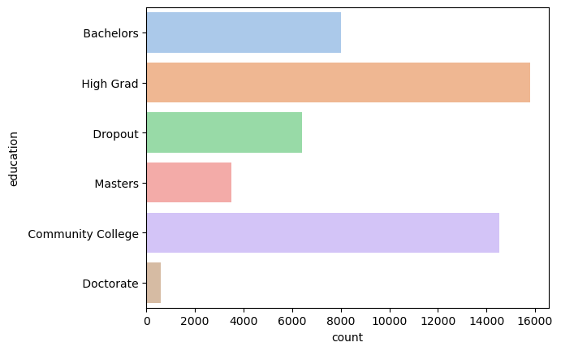

```python
sns.countplot(y = 'education', data = df, palette='pastel');
```

#### Marital-status

```python
df['marital-status'] = df['marital-status'].str.replace('Never-married','Unmarried', regex = True)
df['marital-status'] = df['marital-status'].str.replace('Married-civ-spouse','Married', regex = True)
df['marital-status'] = df['marital-status'].str.replace('Divorced','Separated', regex = True)
df['marital-status'] = df['marital-status'].str.replace('Married-spouse-absent','Married', regex = True)
df['marital-status'] = df['marital-status'].str.replace('Separated','Separated', regex = True)
df['marital-status'] = df['marital-status'].str.replace('Married-AF-spouse','Married', regex = True)
df['marital-status'] = df['marital-status'].str.replace('Widowed','Widowed', regex = True)
df['marital-status'].unique()
```

```
<StringArray>
[' Unmarried', ' Married', ' Separated', ' Widowed']
Length: 4, dtype: string
```

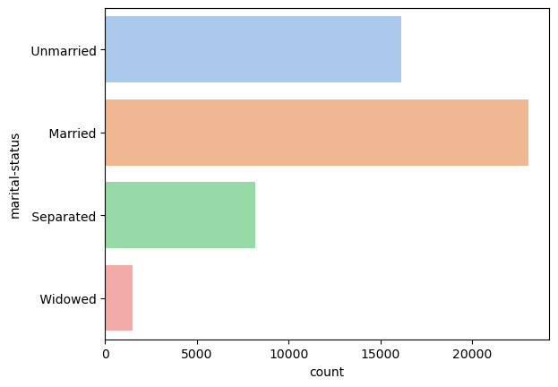

```python
sns.countplot(y = 'marital-status', data = df, palette='pastel');
```

#### Sex

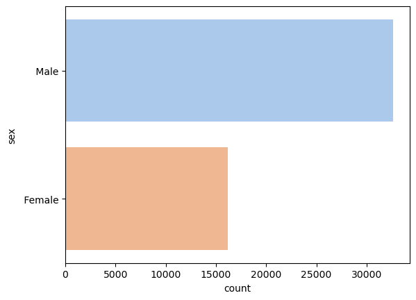

```python
sns.countplot(y = 'sex', data = df, palette='pastel');
```

Male-female ratio is not well distributed. Female population is almost half of Male population.

#### Workclass

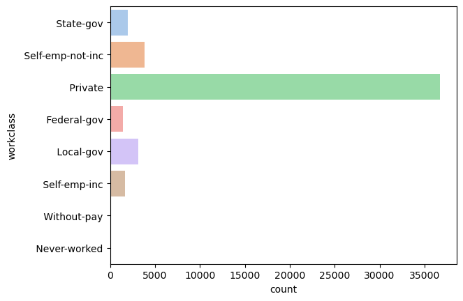

```python
sns.countplot(y = 'workclass', data = df, palette='pastel');
```

#### Occupation

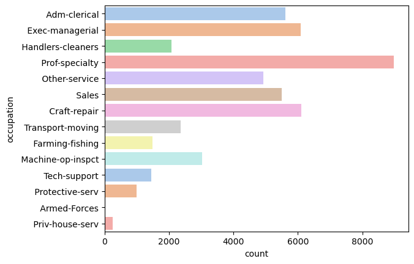

```python
sns.countplot(y = 'occupation', data = df, palette='pastel');
```

#### Target Income

```python
df['target income'] = df['target income'].str.replace('<=50K', '0',regex=False)
df['target income'] = df['target income'].str.replace('<=50K.', '0',regex=False)
df['target income'] = df['target income'].str.replace('>50K', '1', regex=False)
df['target income'] = df['target income'].str.replace('>50K.', '1', regex=False)
df['target income'].unique()
```

```
<StringArray>
[' 0', ' 1', ' 0.', ' 1.']
Length: 4, dtype: string
```

```python
df['target income'] = df['target income'].astype(float)
df['target income'].unique()
```

```
array([0., 1.])
```

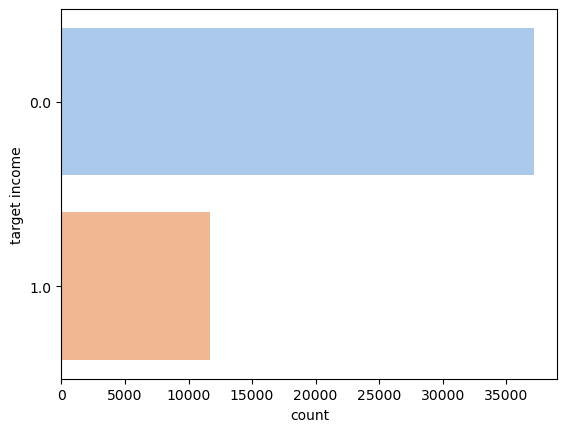

```python
sns.countplot(y = 'target income', data = df, palette='pastel');
```

### Understanding the shape of the data

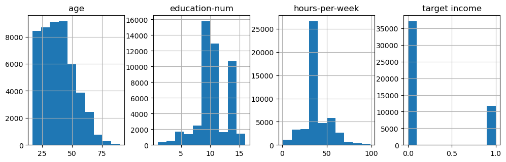

```python
df.hist(figsize =(12,12), layout=(3,4), sharex=False);
```

### Identifying the Outliers

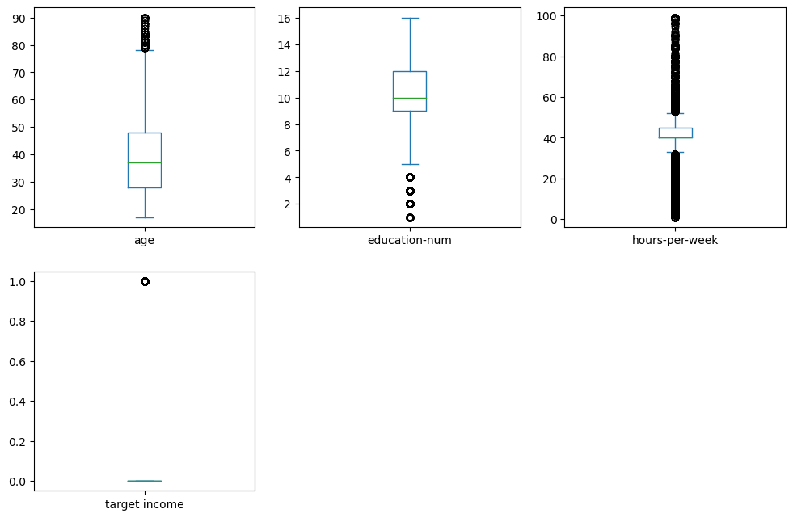

```python
df.plot(kind='box', figsize= (12,12), style=list, layout=(3,3), sharex=False, subplots=True);
```

### Relationship Analysis

```python
# Understanding correlation between each attribute

df.corr()
```

|  | age | education-num | hours-per-week | target income |
| --- | --- | --- | --- | --- |
| age | 1.000000 | 0.030940 | 0.071558 | 0.230369 |
| education-num | 0.030940 | 1.000000 | 0.143689 | 0.332613 |
| hours-per-week | 0.071558 | 0.143689 | 1.000000 | 0.227687 |
| target income | 0.230369 | 0.332613 | 0.227687 | 1.000000 |

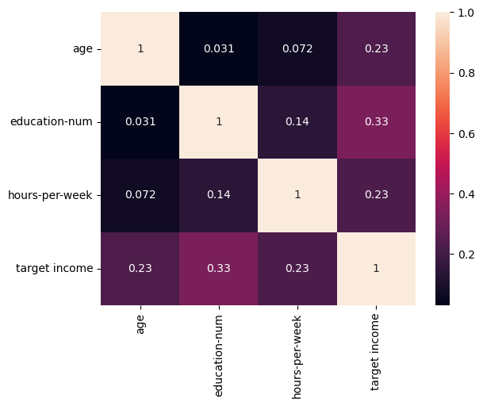

```python
sns.heatmap(df.corr(), annot = True, cbar=True);

# None of the attributes are strongly correlated with each other
```

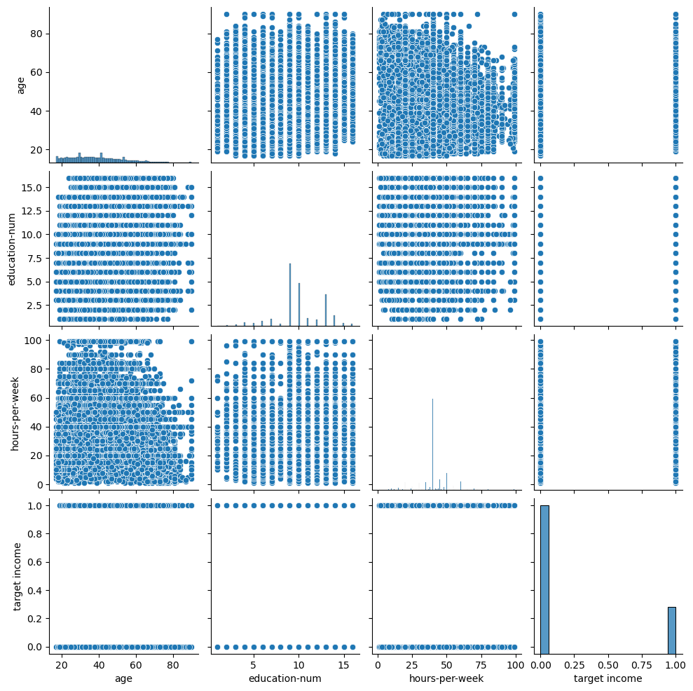

```python
sns.pairplot(df);
```

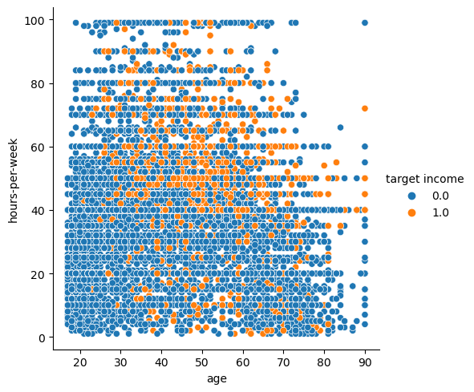

```python
sns.relplot(x='age', y = 'hours-per-week', hue = 'target income', data=df);
```

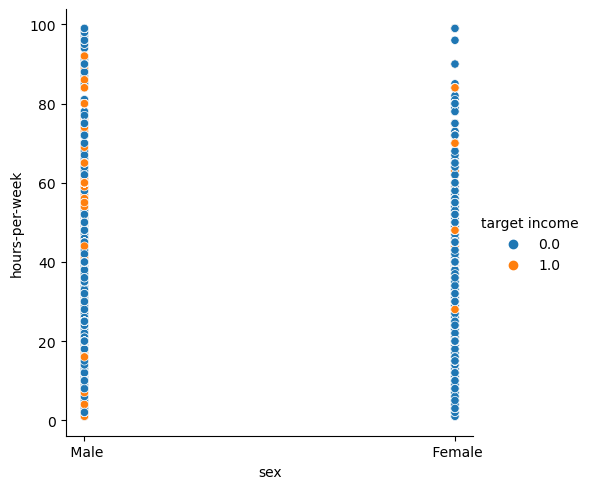

```python
sns.relplot(x='sex', y = 'hours-per-week', hue= 'target income', data=df);
```

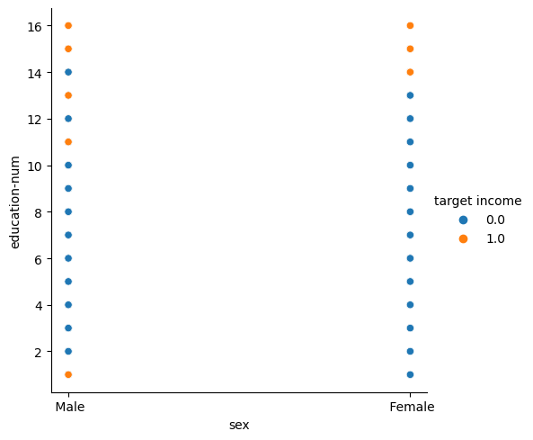

```python
sns.relplot(x='sex', y = 'education-num', hue = 'target income', data=df);
```

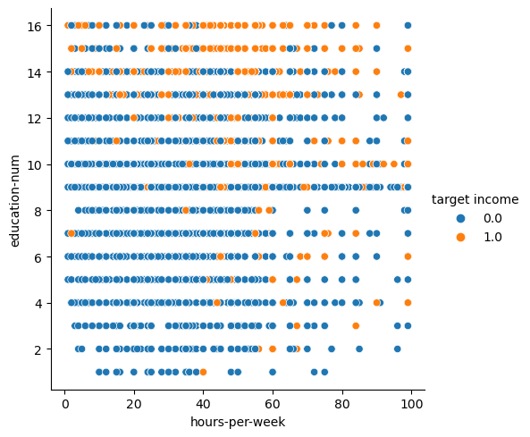

```python
sns.relplot(x='hours-per-week', y = 'education-num', hue = 'target income', data=df);
```

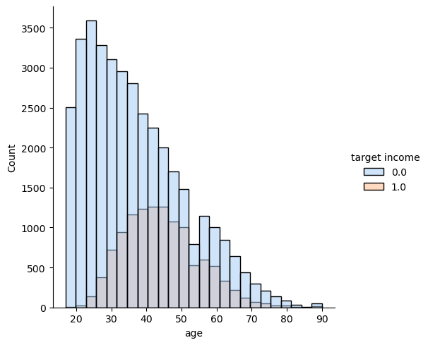

```python
sns.displot(data=df, x='age', hue='target income', palette='pastel', bins=25);
```

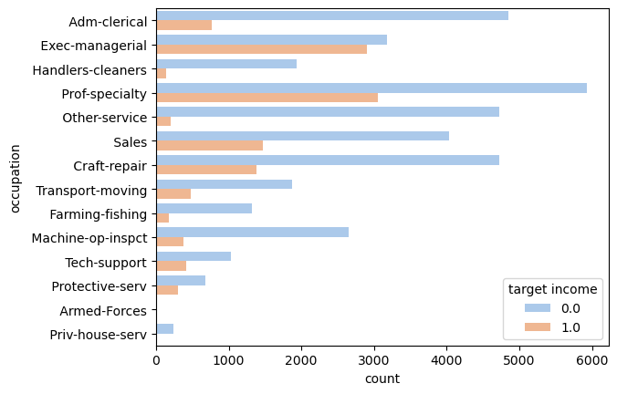

```python
sns.countplot(data=df, y='occupation', hue='target income', palette='pastel');
```

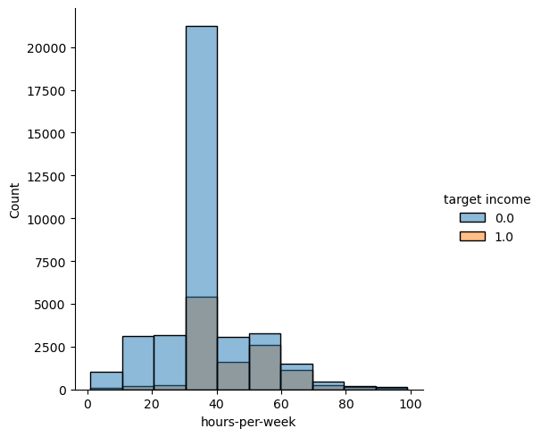

```python
sns.displot(data=df, x='hours-per-week', hue='target income', bins=10);
```

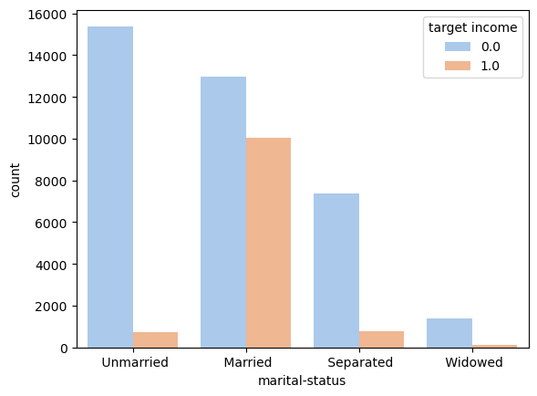

```python
sns.countplot(data=df, x='marital-status', hue='target income', palette='pastel');
```

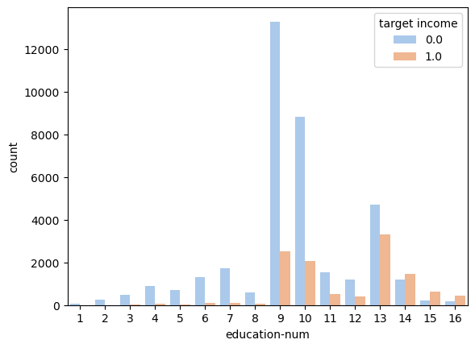

```python
sns.countplot(data=df, x='education-num', hue='target income', palette='pastel');
```

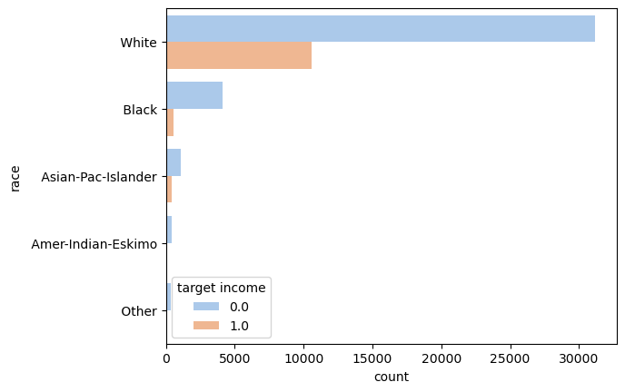

```python
sns.countplot(data=df, y='race', hue='target income', palette='pastel');
```

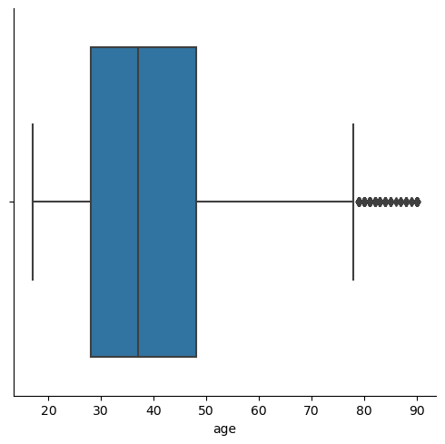

```python
sns.catplot(x='age', kind='box', data=df);
```

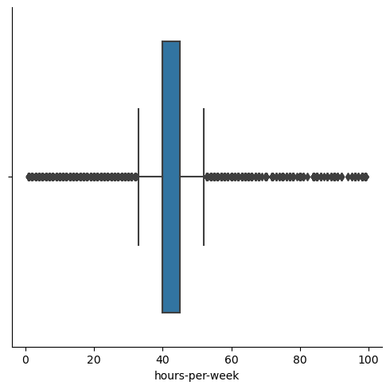

```python
sns.catplot(x='hours-per-week', kind='box', data=df);
```